# Co-expression Networks: Construction and Analysis

Tutorial VT1 | ISCB-Latin America SoIBio SPBBC Conference on Bioinformatics 2026

Dr. Deisy Morselli Gysi | Federal University of Paraná (UFPR), Brazil

2026-11-09

## Today’s Scope

Lithium has treated **bipolar disorder** for more than 70 years, and we still do not fully understand what it does.

**Our question:** in the blood of patients on and off lithium, which genes vary together, how are those relationships organized, and which changes belong to the **disease** and which to the **drug**?

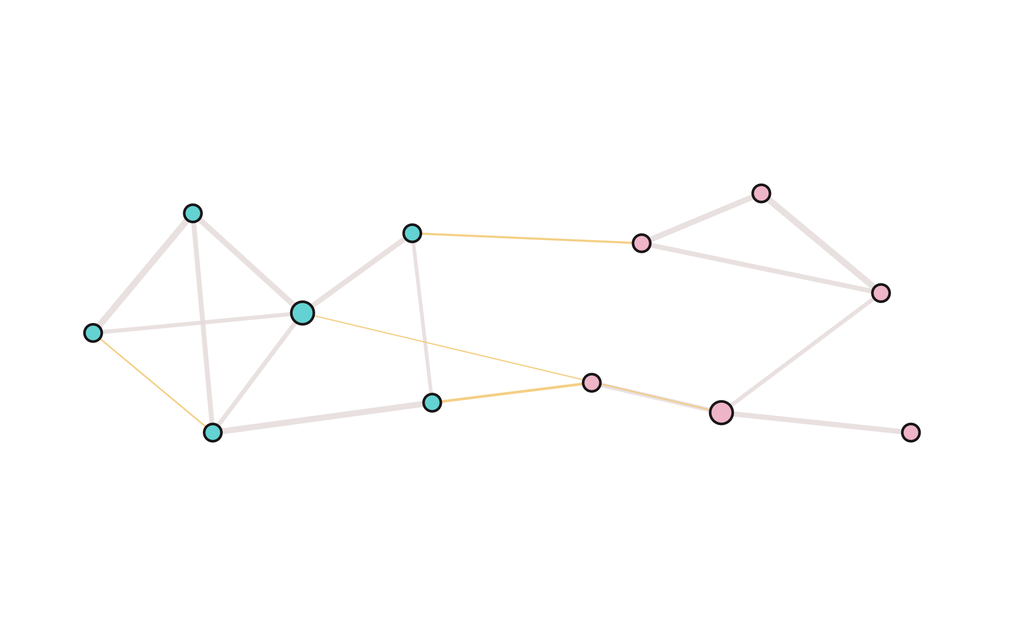

ISCB-Latin America SoIBio SPBBC Conference on Bioinformatics 2026, organized by the Sociedad Peruana de Bioinformática y Biología Computacional (SPBBC), the Iberoamerican Society of Bioinformatics (SoIBio), and the International Society for Computational Biology (ISCB).

## The Course at a Glance

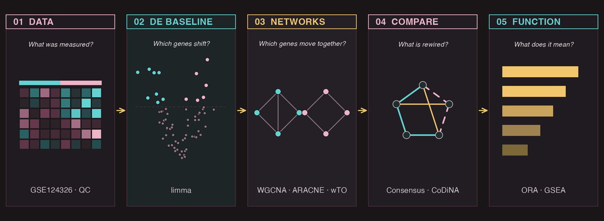

We keep one dataset and one gene set from start to finish, so each step builds on the last: **from measurements, to relationships, to differences, to biology.**

## Learning Outcomes · The Route

By the end of this block, you can:

Graphs

Read a network: degree, hubs, neighbourhoods, and modules.

Data

Prepare GSE124326, remove technical effects, choose the network genes, and set a quick limma baseline.

Networks

Build and compare WGCNA, ARACNE, and wTO networks.

Compare

Find robust links (consensus) and rewired links (CoDiNA).

Function

Interpret modules and gene classes with ORA and GSEA.

Hands-on

Practise every step in the companion notebook, and know each step’s limits.

# Part I · Why Networks?

Graph theory gives us the language; biology gives us the questions.

## Biological Networks Come in Many Flavors

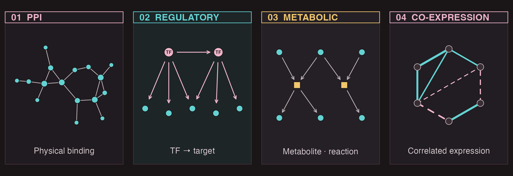

| Network | Nodes | Links mean | Directed? | Typical source |
| --- | --- | --- | --- | --- |
| PPI | Proteins | Physical binding | No | Yeast two-hybrid, AP-MS |
| Regulatory | TFs and targets | Regulation | **Yes** | ChIP-seq, perturbation |
| Metabolic | Metabolites, reactions | Conversion | Yes | Genome-scale models |
| **Co-expression** | Genes | **Similar expression** | No | **Transcriptomes** |

## Graphs and Networks

### Graph · the mathematical object

- $G = (V, E)$: a set of vertices $V$ and edges $E \subseteq V \times V$
- $n = |V|$ vertices, $m = |E|$ edges
- Defined only by **who connects to whom**
- Language: vertices and edges

### Network · the real system

- A graph whose nodes and links **carry meaning and attributes**
- Genes, proteins, metabolites, patients
- Focus on organization, dynamics, and function
- Language: nodes and links

A co-expression network is a **graph built from data**: its nodes are genes, and its links summarize how similarly they vary across samples. Every graph concept we use next applies to it directly.

## What Is a Biological Network?

In a gene network, the nodes are genes and the links join genes that behave alike. Modules and hubs are not put in by hand: they emerge from the pattern of links.

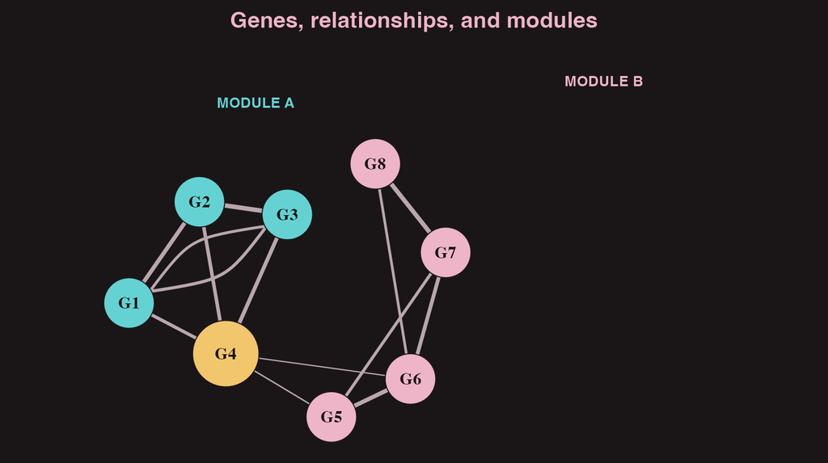

**NODES** are genes.

**LINKS** connect gene pairs; co-expression links are undirected.

**WEIGHT** encodes strength; thicker means stronger.

**MODULES** are dense gene neighborhoods.

**HUBS** have many links; G4 bridges modules.

## Graphs Can Encode Different Relationships

The same nodes can be joined in different ways. An edge can have a direction, a weight for its strength, and a sign that separates positive from negative relationships.

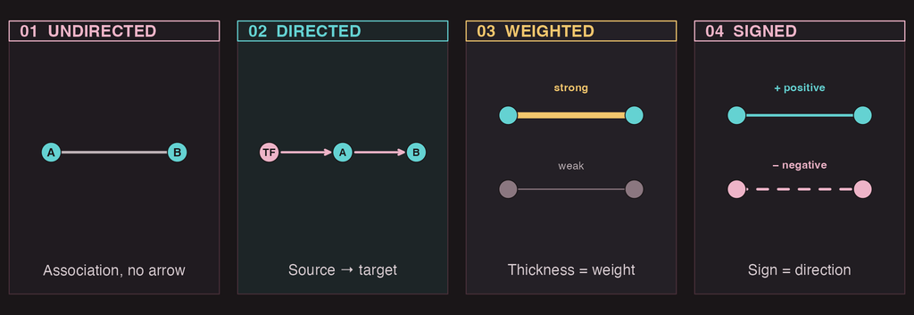

Co-expression networks are typically **undirected, weighted, and signed**. They do not encode causal direction.

## Representing a Network

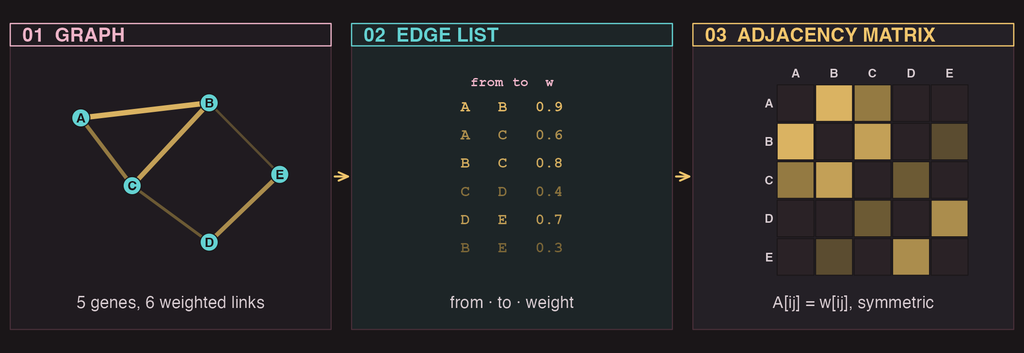

A **correlation matrix is already a dense, weighted adjacency matrix**. Each co-expression method starts from a matrix of this kind. They differ in how they score each pair and which entries they keep.

## Basic Graph Vocabulary

| Concept | Definition | In a gene network |
| --- | --- | --- |
| **Neighbor** | A node joined by an edge | A gene associated with the gene of interest |
| **Degree** $k_i=\sum_j A_{ij}$ | Number of edges at node $i$ | Number of gene associations |
| **Strength** $s_i=\sum_j \|w_{ij}\|$ | Sum of edge weights at node $i$ | Total weighted association (“connectivity” in WGCNA) |
| **Path** | A sequence of connected edges | A route through associated genes |
| **Hub** | Node with unusually many or strong links | Candidate for prioritization, not automatically a regulator |
| **Module** | Densely interconnected group | Candidate coordinated gene program |

These words describe structure only. To say what a hub or a module *does*, we need annotation and, eventually, experiments.

## Degree Distributions: Random vs Scale-free

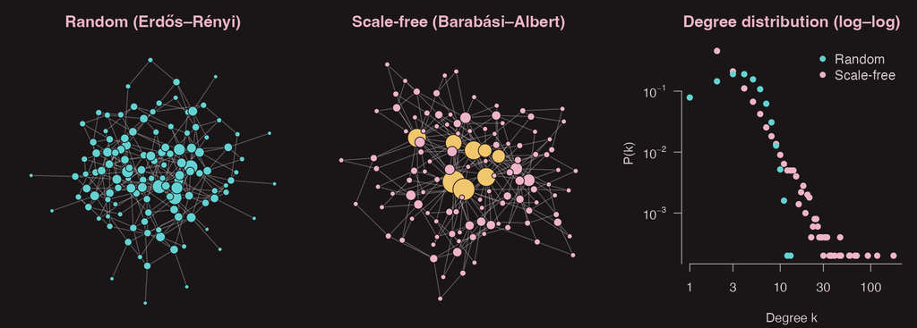

**Random:** degrees cluster around $\langle k \rangle = 2m/n$; hubs are vanishingly rare.

**Scale-free:** $P(k) \sim k^{-\gamma}$, typically $2<\gamma<3$; a few hubs hold many links. **WGCNA uses this shape to choose its soft threshold.**

## Why Does Co-expression Matter?

Genes rarely act alone. When two genes rise and fall together across samples, we draw a strong link between them; when their profiles are unrelated, the link is weak.

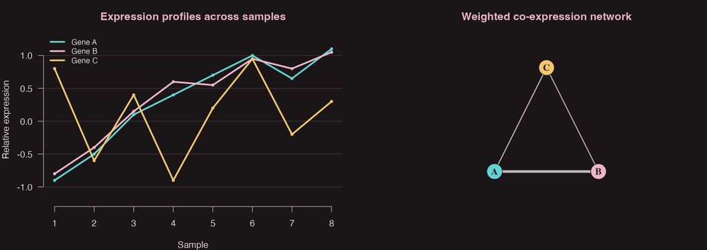

*Simulated profiles, for illustration.*

## Co-expression Is a Pattern, Not a Mechanism

Genes are connected when their expression profiles are statistically similar across samples.

**Useful for:**

- organizing coordinated gene programs
- prioritizing modules and candidate hubs
- comparing network organization between conditions

**Not established by correlation alone:**

- direct physical interaction
- causal regulation
- direction of influence

A link tells us that two genes vary together. *Why* they do is a separate question, and usually an experimental one.

# Part II · Data and Preparation

GSE124326 · whole blood · 112 controls · 226 bipolar I patients, on and off lithium

## Case Study · Lithium in Bipolar Disorder

Whole-blood RNA-seq from **GSE124326** (Krebs *et al.*, 2020), as kept in the authors’ final analysis: **112 controls** and **226 patients with bipolar I disorder**, **152 taking lithium** and **74 not taking it**. The original study found a strong lithium effect on expression; we ask whether lithium also changes **how genes vary together**, and whether we can tell that apart from the disease.

| Input field | Meaning |
| --- | --- |
| `expression` | log<sub>2</sub>-CPM, genes × samples (HGNC symbols) |
| `treatment` | `Control`, `no Lithium` or `Lithium` |
| `sex`, `plate` | Covariates: sex and sequencing plate |
| `neutrophils`, … | Estimated blood-cell fractions |

**CPM** = counts per million: a gene’s reads ÷ the sample’s total reads × 10<sup>6</sup>, so samples sequenced to different depths become comparable. log<sub>2</sub>(CPM) makes the values roughly symmetric. `R/prepare_gse124326.R` builds it from the GEO counts.

Lithium was **not randomized**: differences can reflect lithium, illness course, or co-medication, and lithium **raises neutrophil counts**. Controls were sequenced mostly on plates 3–5, so plate goes into every model.

## Start with the Matrix Contract

Most network packages expect **samples in rows and genes in columns**. Keep the sample metadata aligned to the expression matrix before fitting any model.

|  | Gene A | Gene B | Gene C |
| --- | --- | --- | --- |
| Sample 1 | 4.1 | 7.2 | 2.8 |
| Sample 2 | 4.5 | 6.9 | 3.2 |
| Sample 3 | 3.9 | 7.5 | 2.6 |

```r
input_file <- "data/gse124326_bd_lithium.rds"
stopifnot(file.exists(input_file))
course_data <- readRDS(input_file)

expression_matrix <- course_data$expression   # genes x samples
sample_info <- course_data$sample_info
stopifnot(identical(colnames(expression_matrix), sample_info$sample))
stopifnot(!anyNA(expression_matrix))
```

## Inspect the Matrix and the Design

```r
dim(expression_matrix)
```

```
[1] 13013   338
```

```r
expression_matrix[1:3, 1:4]
```

```
         11R0539 11R0540 11R0541 11R0545
A1BG-AS1   2.020   1.932   1.803   0.640
A2M       -0.193   1.021   0.497  -0.241
A2M-AS1    4.890   5.293   5.499   5.755
```

```r
table(sample_info$treatment, sample_info$sex)
```

```
              F  M
  Control    67 45
  Lithium    90 62
  no Lithium 35 39
```

**Check the orientation:** rows are genes here; transpose only at the package boundary that expects samples × genes. Sex is unbalanced between groups, which is one reason it goes into the model.

## Quality Checks Before Inference

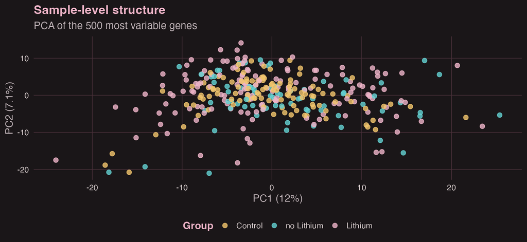

Look for sample outliers, dominant batches, and unexpected group separation. A PCA plot is a diagnostic, not a pass/fail test.

## Check Expression Distributions by Sample

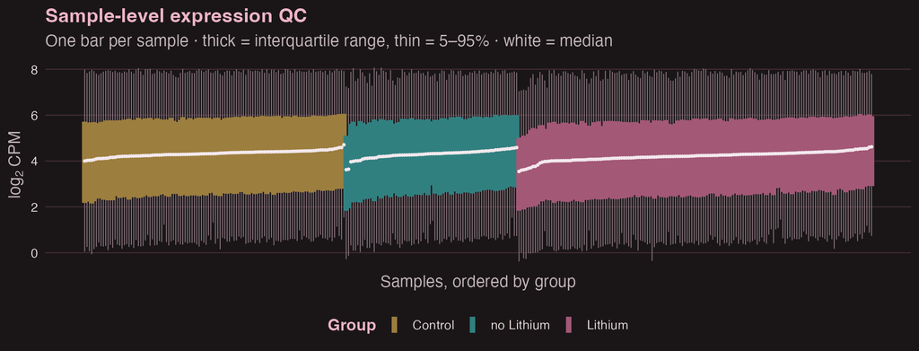

Medians line up because CPM already corrects for sequencing depth. A sample whose box sits apart deserves a closer look before network inference.

## Essential Preprocessing Decisions

Count data need a transformation before correlation-based methods. Which one?

| Transform | Package | Use it when |
| --- | --- | --- |
| log<sub>2</sub>-CPM | edgeR / limma | Simple and transparent; fine with decent depth once low counts are filtered |
| `voom` | limma | DE with limma: log-CPM plus a precision weight per observation |
| `vst` | DESeq2 | Networks, PCA, clustering with **many** samples: fast, stabilizes variance |
| `rlog` | DESeq2 | **Few** samples (≲ 30) with very different library sizes; slow for large studies |

Also: filter lowly expressed genes, check outliers and batches, and keep labels aligned with the matrix. **Here:** log<sub>2</sub>-CPM (338 samples, filtered); sex and plate go into limma and are regressed out before the networks.

The quality of the final network depends more on preprocessing than on the choice of algorithm.

## Select the 2,000 Most Variable Genes

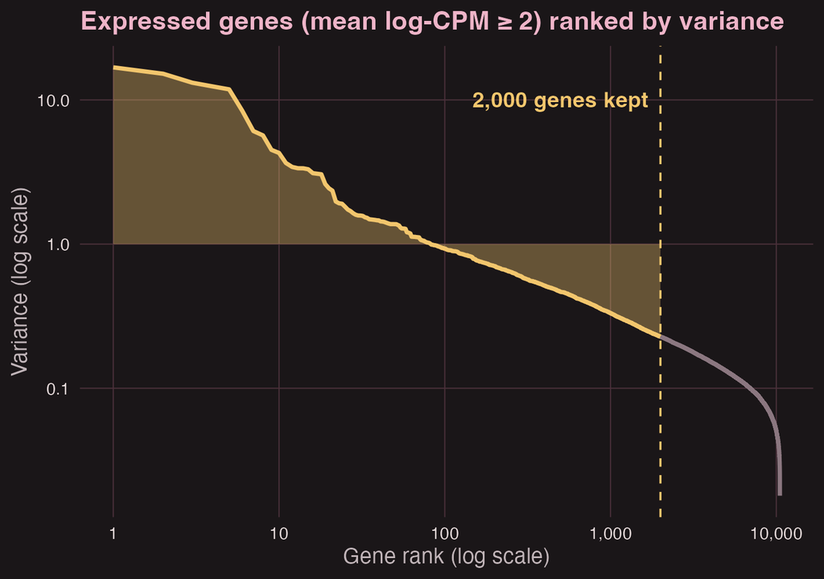

```r
# remove plate and sex, keep the group effects
adjusted_matrix <- limma::removeBatchEffect(
  expression_matrix, batch = sample_info$plate,
  covariates = as.numeric(sample_info$sex == "M"),
  design = treatment_design)
# expressed genes only: low counts are noisy
expressed <- rowMeans(expression_matrix) >= 2
gene_variance <- apply(adjusted_matrix[expressed, ], 1, var)
selected_genes <- names(sort(gene_variance,
                   decreasing = TRUE))[1:2000]
```

**Why adjust first?** Otherwise sex genes (XIST) and plate effects dominate the variance and the network.

**Why expressed, then variance?** At low counts, log values vary mostly by sampling noise; genes that barely vary add noise correlations.

**Why not DEGs?** Choosing genes for differing between groups would build the module–trait association into the selection. A variance filter **ignores the labels**.

## A Quick Baseline · Differential Expression

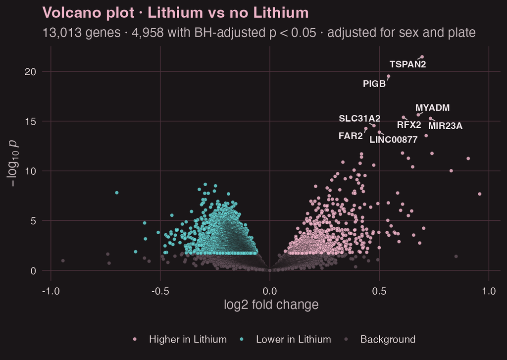

Before building networks, we run the standard analysis once, as a **baseline** to compare against at the end.

One limma model on all expressed genes, adjusted for sex and plate, with two contrasts: **lithium** (on vs off, within bipolar disorder) and **diagnosis** (patients off lithium vs controls).

Lithium moves thousands of genes, each by a little. But DE only sees **changes in average level**. Networks ask whether genes **vary together**, and that is where we spend the rest of the session.

## Hands-on · Data and Gene Selection

**Exercises 1–3** · ≈ 10 min · hands-on notebook, sections 2–4

1. Colour the PCA by treatment, sex, and plate. Which one drives PC1 and PC2?
2. How much variance does `XIST` keep after adjustment? Compare correlations with 2,000 random genes.
3. How many lithium DEGs are there, and how many of them are among the 2,000 network genes?

## Answer · Exercise 1 · What Drives the PCA?

```r
raw_variance <- apply(expression_matrix, 1, var)
top500 <- names(sort(raw_variance,
                     decreasing = TRUE))[1:500]
pca <- prcomp(t(expression_matrix[top500, ]),
              scale. = TRUE)
# ANOVA p-value: does each variable explain PC1/PC2?
pc_p <- function(v) sapply(1:2, function(k)
  anova(lm(pca$x[, k] ~ sample_info[[v]]))[1, 5])
pc_pvals <- sapply(c("treatment", "sex", "plate"),
                   pc_p)
rownames(pc_pvals) <- c("PC1", "PC2")
signif(pc_pvals, 2)
##     treatment   sex   plate
## PC1     0.190 0.069 8.0e-16
## PC2     0.047 0.560 8.2e-01
```

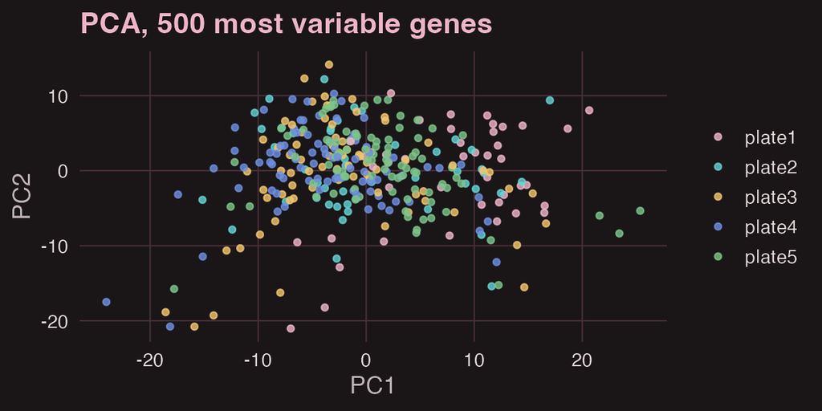

**Sequencing plate** drives PC1 (p = 8e-16). Sex and treatment barely show on the first two PCs, even though `XIST` is the single most variable gene: one gene does not make a principal component. That is why plate and sex go into the model.

## Answer · Exercise 2 · Adjust, Then Filter

```r
rank_of <- function(v, g)
  match(g, names(sort(v, decreasing = TRUE)))
v0 <- raw_variance; v1 <- gene_variance
xist <- rbind(
  variance = c(v0[["XIST"]], v1[["XIST"]]),
  rank = c(rank_of(v0, "XIST"),
           rank_of(v1, "XIST")))
colnames(xist) <- c("before", "after")
round(xist, 2)
##          before after
## variance  22.81  0.96
## rank       1.00 92.00
```

```r
set.seed(1)
random_genes <- sample(rownames(adjusted_matrix), 2000)
abs_cor <- function(g) {
  C <- cor(t(adjusted_matrix[g, ])); abs(C[upper.tri(C)])
}
pc1 <- function(g)
  prcomp(t(adjusted_matrix[g, ]), scale. = TRUE)$x[, 1]
neu <- sample_info$neutrophils
rbind(median_abs_r = c(median(abs_cor(selected_genes)),
                       median(abs_cor(random_genes))),
      pc1_vs_neutrophils = c(cor(pc1(selected_genes), neu),
                             cor(pc1(random_genes), neu))) |>
  `colnames<-`(c("top_2000", "random")) |> round(2)
##                    top_2000 random
## median_abs_r           0.15   0.20
## pc1_vs_neutrophils    -0.58   0.73
```

**(a)** Adjustment removes the female–male difference, so `XIST` loses most of its variance (22.8 → 0.96). It still varies between women, so it can stay among the top 2,000.

**(b)** The random genes correlate **more**, and the first PC of **both** sets follows the neutrophil fraction (a PC’s sign is arbitrary: read |r|). In whole blood, the mix of cell types moves thousands of genes together. Strong correlation is not automatically interesting structure: ask what drives it.

## Answer · Exercise 3 · How Much DE Reaches the Network?

```r
c(lithium_DEGs = sum(limma_results$adj.P.Val < 0.05),
  diagnosis_DEGs = sum(diagnosis_results$adj.P.Val < 0.05),
  in_network = sum(limma_results[selected_genes, "adj.P.Val"] < 0.05))
##   lithium_DEGs diagnosis_DEGs     in_network
##           4958            495            560
```

Thousands of genes pass FDR for lithium, mostly with small fold changes: with 338 samples, small shifts are detectable. The diagnosis contrast finds fewer. DEGs are **under-represented** among the most variable genes: 28% of the network genes vs 38% genome-wide. In blood, variance is dominated by differences between people (HLA genotype, cell mix), not by lithium.

# Part III · Building Networks

Three ways to define a link · WGCNA · ARACNE · wTO

## From Expression Data to Networks

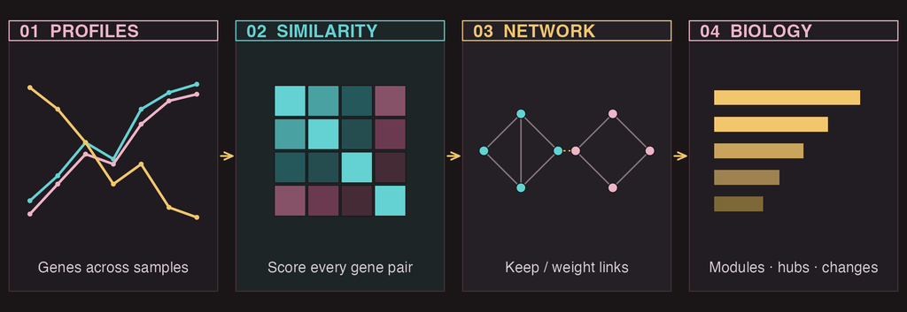

The methods differ in **how they score a pair** (correlation, mutual information, shared neighbors) and **which links they keep**.

```r
network_matrix <- adjusted_matrix[selected_genes, , drop = FALSE]  # plate/sex removed
dat_expr <- t(network_matrix)
dim(dat_expr)  # samples x genes for network methods
```

```
[1]  338 2000
```

## WGCNA · From Correlation to Modules

WGCNA turns pairwise gene correlations into a weighted network, groups genes by shared neighbors, and summarizes each module with an eigengene.

$$a_{ij} = \left(\frac{1 + \mathrm{cor}(x_i, x_j)}{2}\right)^\beta$$

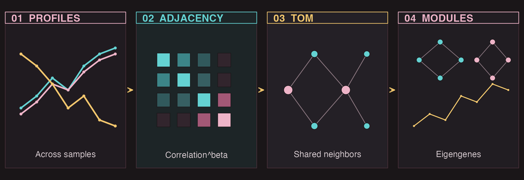

**Output:** modules and eigengenes for trait association. Boundaries depend on the gene set, soft power, and clustering settings; they are not functional annotations by themselves.

## WGCNA · The Method, Step by Step

**1 · Similarity.** Signed: $s_{ij}=\tfrac{1+r_{ij}}{2}$ · unsigned: $s_{ij}=|r_{ij}|$

**2 · Soft threshold.** $a_{ij}=s_{ij}^{\beta}$: keep every link, but suppress weak ones. Choose $\beta$ so that $\log P(k)$ vs $\log k$ is close to linear.

**3 · Topological overlap.**
$$\mathrm{TOM}_{ij}=\frac{\sum_u a_{iu}a_{uj}+a_{ij}}{\min(k_i,k_j)+1-a_{ij}}$$

**4 · Clustering.** Average-linkage tree on $1-\mathrm{TOM}$; **dynamic tree cut** defines modules (`minModuleSize`).

**5 · Eigengene.** $\mathrm{ME}_q$ = first principal component of the module’s scaled expression. Modules with $\mathrm{cor}(\mathrm{ME}) > 1-$`mergeCutHeight` merge.

**6 · Membership (kME).** **kME** = *eigengene-based connectivity*: the correlation of gene $i$ with its module’s eigengene, $k\mathrm{ME}_{i}=\mathrm{cor}(x_i,\mathrm{ME}_q)$. Near 1, the gene follows the module closely; the highest are **intramodular hubs**.

## WGCNA · Signed vs Unsigned Networks

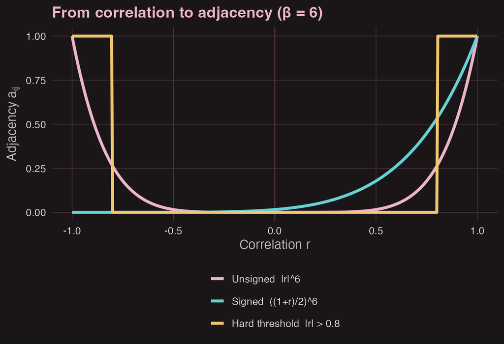

**Unsigned:** genes with $r=-0.9$ are as linked as those with $r=+0.9$. Modules mix opposite patterns.

**Signed:** only positive co-expression produces strong links. Modules hold genes that **rise and fall together**, which makes eigengenes easier to interpret.

**Soft vs hard:** a hard cutoff throws away information and is sensitive to the cutoff; soft thresholding keeps a continuous weight.

We use **signed** networks.

## WGCNA · Choosing a Soft-thresholding Power

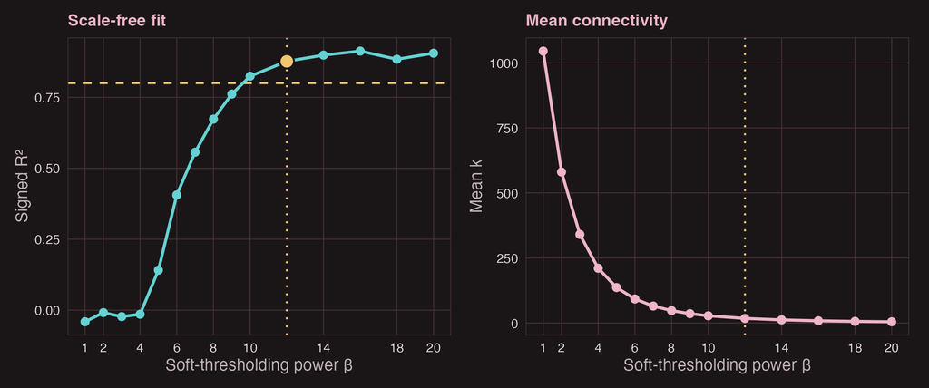

Pick the lowest $\beta$ where the fit plateaus near **R² ≈ 0.8** without letting connectivity collapse. Here WGCNA’s estimate is β = 12 (R² = 0.88, mean k = 18), and that is what we use.

## Run a Small, Reproducible WGCNA

```r
soft_power <- power_diagnostic$powerEstimate  # from the soft-threshold diagnostic
wgcna_fit <- WGCNA::blockwiseModules(
  dat_expr,
  power = soft_power,
  networkType = "signed",
  TOMType = "signed",
  minModuleSize = 20,
  mergeCutHeight = 0.25,
  randomSeed = 20261109,
  verbose = 0
)
module_colors <- as.character(wgcna_fit$colors)  # already colour names
names(module_colors) <- colnames(dat_expr)
module_eigengenes <- WGCNA::orderMEs(wgcna_fit$MEs)
table(module_colors)
```

```
module_colors
      black        blue       brown       green greenyellow        grey
        112         334         255         143          30         172
    magenta        pink      purple         red         tan   turquoise
         80          84          38         116          26         426
     yellow
        184
```

**One network for everyone.** WGCNA runs **once**, on all 338 samples (controls and patients together); the groups enter only afterwards, when module eigengenes are related to traits.

## WGCNA · Visualize the Module Dendrogram

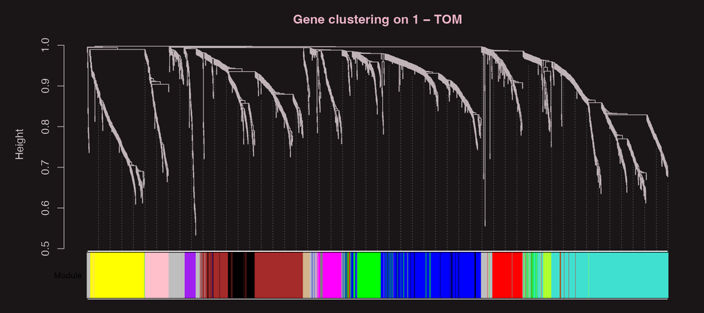

Each leaf is a gene; branches that merge low are genes with highly overlapping neighborhoods. The color strip is the module assignment from dynamic tree cut.

## WGCNA · The Module Network

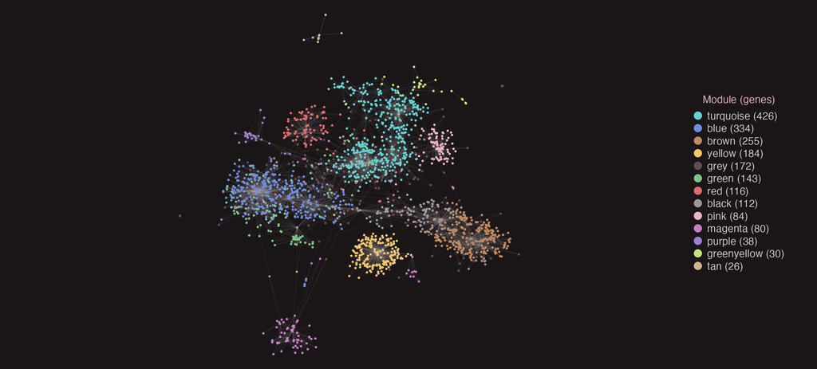

All 2,000 genes of the single network, each linked to its **3 strongest TOM partners**. Each colour is a module: modules appear as dense neighbourhoods, and the links between them are genes that share partners across modules.

## WGCNA · Relate Modules to the Phenotype

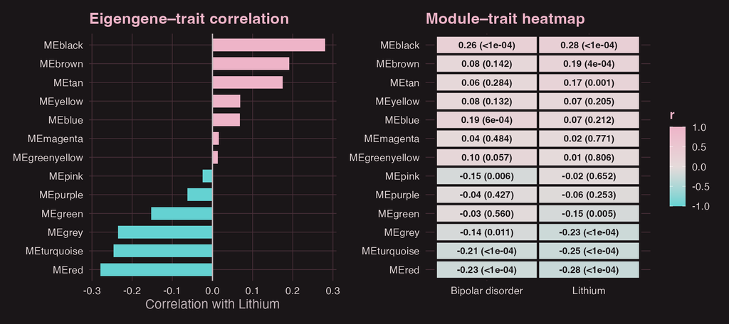

Two binary traits over all 338 samples: **bipolar disorder** (patients vs controls) and **lithium** (on lithium vs everyone else). Correlation with a 0/1 indicator is a two-group comparison of eigengenes: association, not causation.

## WGCNA · Compare Eigengenes by Condition

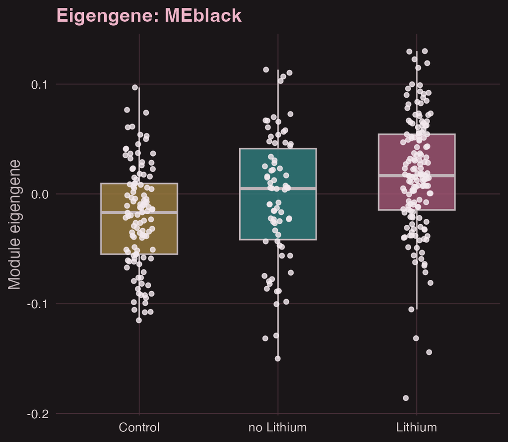

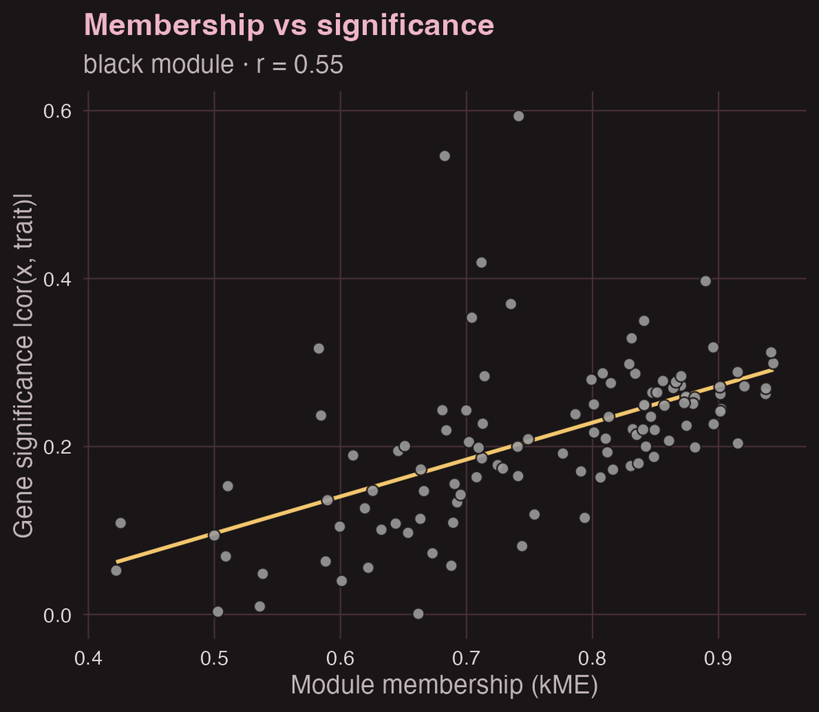

**Reading it:** when kME and gene significance correlate positively, the module’s most central genes are also the most trait-associated, which makes them candidate drivers. Here $r =$ 0.55, so that pattern holds for the black module. These are the genes to follow up first. The grey bin holds unassigned genes and is never interpreted as a module.

## WGCNA · Intramodular Hubs

| Gene | kME | GS | logFC | FDR |
| --- | --- | --- | --- | --- |
| RNF24 | 0.94 | 0.30 | +0.25 | 0.0135 |
| KDM6B | 0.94 | 0.31 | +0.29 | 0.0041 |
| PXN | 0.94 | 0.27 | +0.19 | 0.0231 |
| NOTCH1 | 0.94 | 0.26 | +0.20 | 0.0213 |
| FMNL1 | 0.92 | 0.27 | +0.21 | 0.0255 |
| GAB2 | 0.92 | 0.20 | +0.14 | 0.0840 |
| RASGRP4 | 0.92 | 0.29 | +0.26 | 0.0030 |
| KMT2D | 0.90 | 0.24 | +0.17 | 0.0831 |
| C15orf39 | 0.90 | 0.26 | +0.19 | 0.0421 |
| NBEAL2 | 0.90 | 0.24 | +0.14 | 0.1522 |

The ten genes most representative of the black module: highest **kME**, the correlation of each gene with the module eigengene. GS = gene significance, |cor(gene, lithium)|; logFC and FDR come from limma.

A hub summarizes how its module behaves; being central does not make it a regulator.

Hubs with **high kME but no DE signal** are exactly the genes a DEG-only analysis would miss.

## Hands-on · WGCNA

**Exercises 4–5** · ≈ 10 min · hands-on notebook, section 5

4. Re-run WGCNA with `power = 6`. How many modules remain? How many genes become grey?
5. Which eigengene correlates most with lithium? List its 10 top-kME genes.

## Answer · Exercise 4 · A Lower Soft Power

```r
fit6 <- WGCNA::blockwiseModules(
  dat_expr, power = 6, networkType = "signed",
  TOMType = "signed", minModuleSize = 20,
  mergeCutHeight = 0.25, randomSeed = 20261109,
  verbose = 0)
fit6_colors <- as.character(fit6$colors)
n_mod <- function(m) length(setdiff(unique(m), "grey"))
data.frame(
  power = c(soft_power, 6),
  modules = c(n_mod(module_colors), n_mod(fit6_colors)),
  grey = c(sum(module_colors == "grey"),
           sum(fit6_colors == "grey")))
##   power modules grey
## 1    12      12  172
## 2     6      10  231
```

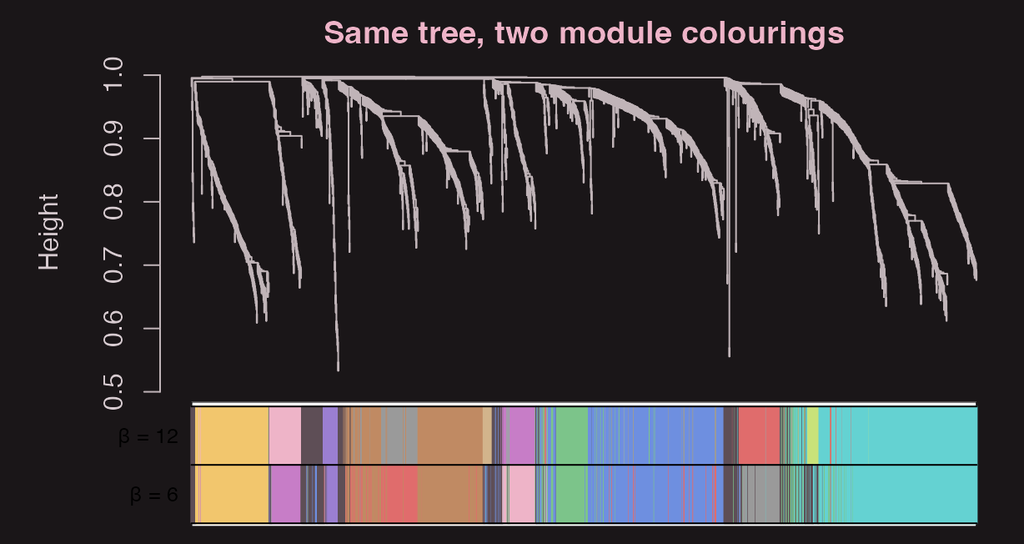

The power changes the partition: β = 6 gives **10** modules and **231** grey genes, against 12 and 172 at β = 12. Where one module ends and the next begins is partly a choice, so report the power you used.

## Answer · Exercise 5 · The Lithium Module and Its Hubs

```r
mt <- module_trait[module_trait$module != "MEgrey",
                   c("module", "correlation")]
head(mt[order(-abs(mt$correlation)), ], 3)
##        module correlation
## 4     MEblack   0.2807353
## 6       MEred  -0.2792545
## 2 MEturquoise  -0.2460128
kme_top <- setNames(kme_matrix[[paste0("kME", top_color)]],
                    rownames(kme_matrix))
hubs <- head(sort(kme_top[module_colors == top_color],
                  decreasing = TRUE), 10)
round(hubs, 2)
##    RNF24    KDM6B      PXN   NOTCH1    FMNL1     GAB2
##     0.94     0.94     0.94     0.94     0.92     0.92
##  RASGRP4    KMT2D C15orf39   NBEAL2
##     0.92     0.90     0.90     0.90
```

The black eigengene correlates most with lithium (r = 0.28). Its top-kME genes, led by **RNF24**, best represent the module’s expression pattern.

They are the first genes to follow up, but being central does not make a gene a regulator.

## ARACNE · How It Works

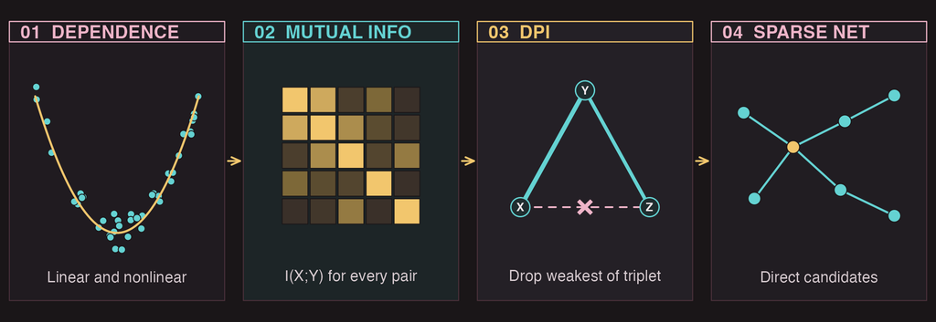

**What it asks:** which gene pairs show statistical dependence, including nonlinear dependence? Mutual information (MI) scores every pair, and the data processing inequality (DPI) prunes likely indirect links. The result is a sparse, undirected network. It does not show causal direction.

## ARACNE · Correlation Can Miss Dependence

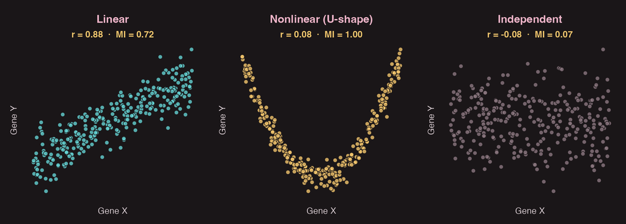

$$I(X;Y)=\sum_{x,y}p(x,y)\log\frac{p(x,y)}{p(x)\,p(y)}\qquad I=0 \iff X \perp Y$$

MI is zero only under independence, so it detects the U-shape that correlation misses. The cost is that MI needs **more samples** to estimate reliably.

## ARACNE · The Data Processing Inequality

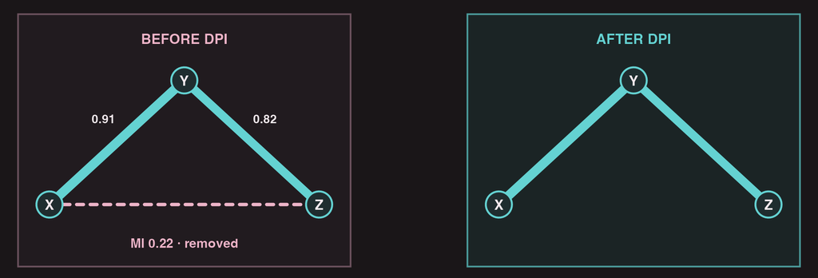

If $X \to Y \to Z$ is a chain, information about $Z$ in $X$ cannot exceed what flows through $Y$:
$$I(X;Z) \le \min\{I(X;Y),\, I(Y;Z)\}$$

ARACNE inspects **every triplet** and removes its weakest edge, unless it is within a tolerance `eps` of the others. With `estimator = "spearman"`, minet uses the Gaussian form $I=-\tfrac12\log(1-\rho^2)$.

## ARACNE · Run Mutual-Information Inference

```r
mi_matrix <- minet::build.mim(dat_expr, estimator = "spearman")  # samples x genes
aracne_matrix <- minet::aracne(mi_matrix, eps = 0)
c(edges = sum(aracne_matrix > 0) / 2,
  density = round(mean(aracne_matrix[upper.tri(aracne_matrix)] > 0), 4))
```

```
    edges   density
2685.0000    0.0013
```

**One network** from all 338 samples, as with WGCNA. **Input:** samples × genes. `build.mim()` estimates pairwise MI; `aracne()` applies DPI. **Output:** a sparse, symmetric adjacency matrix of MI values. Read each edge as statistical dependence, not regulation.

## ARACNE · The Inferred Network

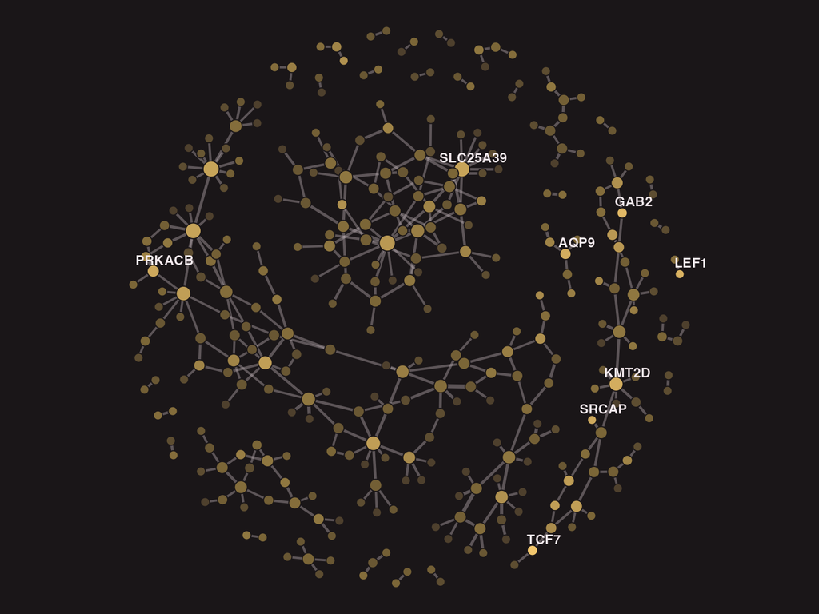

The strongest **350 ARACNE edges** of the single network.

Node colour = degree in the full ARACNE network; size = degree among the edges shown. Labels mark the 8 biggest **hubs**.

DPI keeps only **direct** dependencies, so the network is sparse and tree-like: hubs are genes with many non-redundant partners.

## Hands-on · ARACNE

**Exercise 6** · ≈ 6 min · hands-on notebook, section 6

6. Take the 50 genes with the highest ARACNE degree. Which WGCNA modules are they in? How many are also top-50 kME genes of the trait-associated module?

## Answer · Exercise 6 · ARACNE Hubs vs WGCNA Hubs

```r
aracne_hubs <- names(sort(rowSums(aracne_matrix > 0),
                          decreasing = TRUE))[1:50]
sort(table(module_colors[aracne_hubs]), decreasing = TRUE)
##
##      blue turquoise     brown     black      grey
##        12        11         6         4         4
##    yellow     green   magenta       red       tan
##         4         3         3         2         1
kme_top50 <- names(head(sort(kme_top[module_colors == top_color],
                             decreasing = TRUE), 50))
length(intersect(aracne_hubs, kme_top50))
## [1] 4
```

**4** genes are hubs in both. The ARACNE hubs spread over **10** WGCNA modules.

The methods define importance differently: a WGCNA hub sits at the centre of one module; DPI keeps only **direct** links, so ARACNE hubs have many non-redundant partners, often bridging modules. Genes found by both are the more robust candidates.

## wTO · How It Works

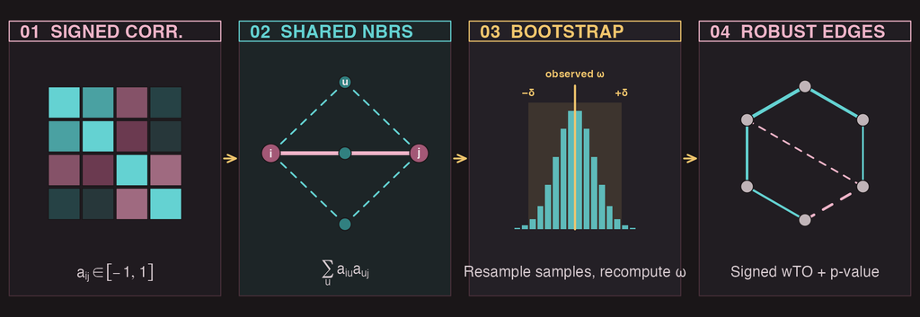

**Idea:** two genes are strongly linked when they correlate **and** share many neighbors with the same sign. Unlike TOM, wTO keeps the **sign**, so positive and negative co-regulation stay distinguishable.

## wTO · The Formula

$$\omega_{ij}=\frac{\displaystyle\sum_{u\neq i,j}a_{iu}\,a_{uj}+a_{ij}}{\min(k_i,k_j)+1-|a_{ij}|}$$

with $a_{ij}\in[-1,1]$ the signed correlation and $k_i=\sum_{u}|a_{iu}|$.

- $\omega_{ij}\in[-1,1]$; the sign tells **concordant** vs **opposite** co-regulation.
- Neighbors **reinforce** the link when $a_{iu}a_{uj}$ agrees in sign with $a_{ij}$; they **weaken** it otherwise.
- **Bootstrap:** resample the samples with replacement and recompute $\omega$ many times. The p-value is the share of resamples in which $\omega$ moved by more than $\delta$: small = a **stable** link.

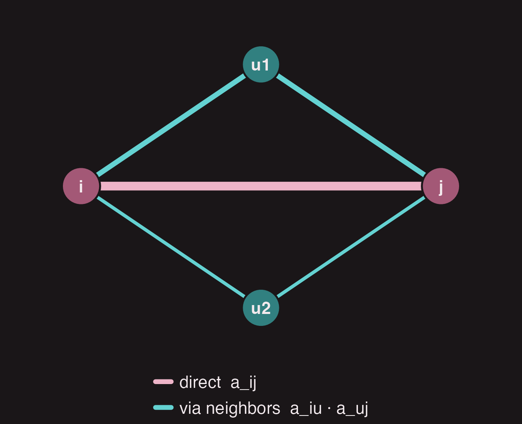

## wTO · Estimate Signed Topological Overlap

```r
source("R/wto_fast.R")  # vectorised wTO::wTO.fast(); identical output, much faster
# One network per group, all 2,000 genes, 100 bootstrap resamples.
# Built once (~15 min) and cached in results/wto_cache_2k.rds.
wto_nets <- load_wto_networks(network_matrix, sample_info, n = 100)
wto_control <- wto_nets$control
wto_nolithium <- wto_nets$no_lithium
wto_lithium <- wto_nets$lithium
sapply(list(control = wto_control, no_lithium = wto_nolithium, lithium = wto_lithium),
       function(x) c(pairs = nrow(x), stable = sum(x$pval.adj < 0.05)))
```

```
       control no_lithium lithium
pairs  1999000    1999000 1999000
stable 1868928    1244632 1955501
```

```r
head(wto_lithium, 3)
```

```
     Node.1   Node.2   wTO  pval pval.adj
     <char>   <char> <num> <num>    <num>
1: HLA-DQB1 HLA-DQA1 0.123     0        0
2: HLA-DQB1 HLA-DRB1 0.077     0        0
3: HLA-DQA1 HLA-DRB1 0.113     0        0
```

`wto_fast()` reproduces `wTO::wTO.fast()` exactly (same bootstrap, same p-values); it only vectorises one internal step. The p-value is **stability**: the share of resamples in which $\omega$ moved by more than $\delta = 0.2$.

## wTO · Modules in Each Group

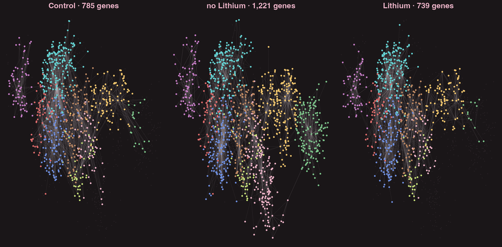

Only links with bootstrap $p_{adj}<0.001$ **and** $|\omega|>0.4$; each gene is drawn with its **3 strongest partners**, as in the WGCNA module network. Colours = 9 **communities** (Louvain) found on the three groups together, so the same colour means the same module in every panel. Watch which modules **appear, shrink, or vanish** between groups.

## How to Read a wTO Edge

| Field | What it records |
| --- | --- |
| `Node.1`, `Node.2` | The gene pair |
| `wTO` | Signed weighted topological overlap, $\omega_{ij}\in[-1,1]$ |
| `pval` | Share of bootstrap resamples in which $\omega_{ij}$ moved by more than $\delta$ |
| `pval.adj` | BH-adjusted `pval`: small means a **stable** link |

`wTO.Complete()` adds signed/absolute variants and resampling choices; `wTO.fast()` returns these five columns. Stability and strength are different: inspect both before setting an edge threshold.

## Hands-on · wTO

**Exercise 7** · ≈ 8 min · hands-on notebook, section 7

7. List the 10 strongest stable links in each condition. How many pairs are stable in both but **flip sign**?

## Answer · Exercise 7 · Strongest Links and Sign Flips

```r
stable <- function(x) filter(x, pval.adj < 0.05)
top_links <- function(x) stable(x) |>
  arrange(desc(abs(wTO))) |> head(3) |>
  transmute(link = paste(Node.1, Node.2, sep = "–"), wTO)
top_links(wto_control)
##            link   wTO
##          <char> <num>
## 1:  RPL11–ZNF22 0.499
## 2: ZNF22–NDUFA5 0.497
## 3: ZNF22–ZNF761 0.497
top_links(wto_lithium)
##             link   wTO
##           <char> <num>
## 1:    ZNF22–SNX4 0.477
## 2: ZCCHC10–ZNF22 0.473
## 3:  GIMAP2–ZNF22 0.473
both <- inner_join(stable(wto_control), stable(wto_lithium),
                   by = c("Node.1", "Node.2"),
                   suffix = c(".ctrl", ".li"))
c(stable_in_both = nrow(both),
  sign_flips = sum(sign(both$wTO.ctrl) != sign(both$wTO.li)))
## stable_in_both     sign_flips
##        1854065         279219
```

**279,219** of the 1,854,065 pairs that are stable in both controls and lithium-treated patients **flip sign**.

Sign flips are the raw material of CoDiNA’s **β** class. Lithium was not randomized, so treat them as hypotheses.

# Part IV · Comparing Networks

Consensus: what is robust? · CoDiNA: what changed?

## Consensus Networks · How It Works

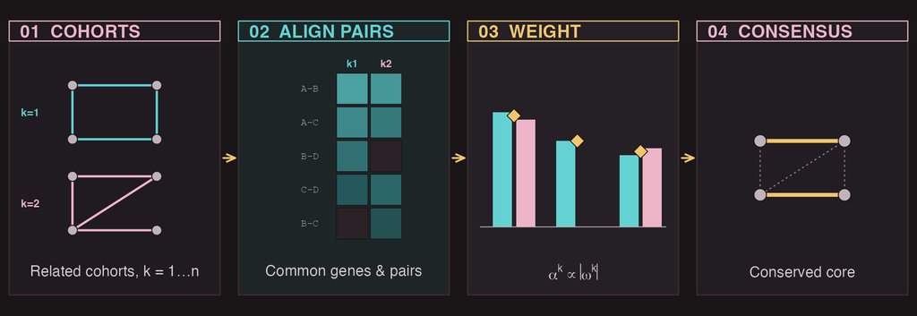

$$\Omega_{ij}=\sum_{k=1}^{n}\alpha_{ij}^{k}\,\omega_{ij}^{k},\qquad \alpha_{ij}^{k}=\frac{|\omega_{ij}^{k}|}{\sum_{k}|\omega_{ij}^{k}|}$$

Each dataset contributes in proportion to its edge strength, so a link that is strong everywhere stays strong. `wTO.Consensus()` also combines the per-cohort p-values with **Fisher’s method**.

## Consensus · A Worked Example

```r
as_wto_input <- function(x) data.frame(
  Node.1 = factor(x$Node.1), Node.2 = factor(x$Node.2),
  wTO = x$wTO, pval = x$pval)
# bipolar network: patients off + on lithium
consensus <- wTO::wTO.Consensus(list(
  as_wto_input(wto_nolithium),
  as_wto_input(wto_lithium)))
# |wTO| peaks near 0.4 here
robust <- consensus |>
  mutate(padj = p.adjust(pval.fisher, "BH")) |>
  filter(abs(CN) >= 0.3, padj < 0.05)
nrow(robust)
```

```
[1] 275044
```

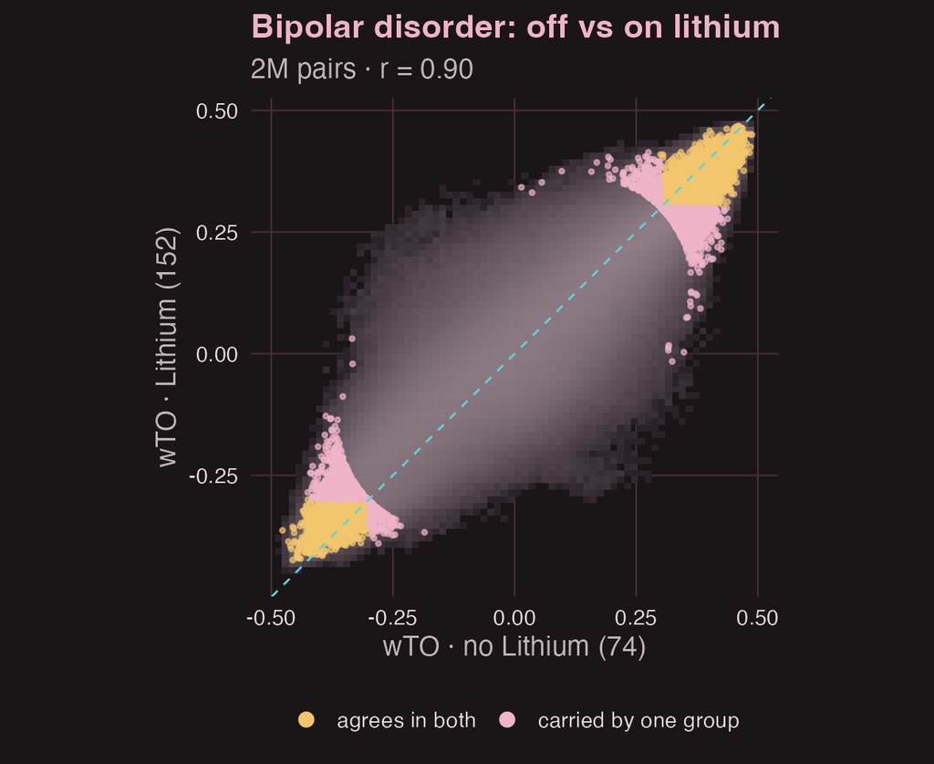

We combine the networks of patients **off** (74) and **on** (152) lithium into one **bipolar-disorder consensus**: links that hold whatever the treatment. Of the 275,044 consensus links, 188,173 agree in both and 86,871 are carried by one group: weighting by $|\omega|$ lets the stronger network dominate. **Check per-network agreement.**